# AMLHC - Final Exam - Jannis Vollmer

Jannis Vollmer

```r
  require(caret)
```

# 1 Introduction

The following Notebook analyses the data set “Cirrhosis Patient Survival Prediction” by the Mayo Clinic from the years 1974 to 1984. The question to answer with this data set is, if it is possible to predict the survival state of patients with liver cirrhoses. Cirrhosis is a disease, caused by liver damage and leads to extensive scarring. The main origin is often Hepatitis or heavy and constant alcohol consumption.

# 2 Description of the data set

## 2.1 Variable description

The following table explains what content is behind each variable in the data set. The target variable is the “Status”. The other ones, except the “ID” and “N_Days” are Feature variables.

| Variable Name | Description | Role |
| --- | --- | --- |
| ID | unique identifier | Other |
| N_Days | number of days between registration and the earlier of death, transplantation, or study analysis time in July 1986 | Other |
| Status | status of the patient C (censored), CL (censored due to liver tx), or D (death) | Target |
| Drug | type of drug D-penicillamine or placebo | Feature |
| Age | age in days | Feature |
| Sex | M (male) or F (female) | Feature |
| Ascites | presence of ascites N (No) or Y (Yes) | Feature |
| Hepatomegaly | presence of hepatomegaly N (No) or Y (Yes) | Feature |
| Spiders | presence of spiders N (No) or Y (Yes) | Feature |
| Edema | presence of edema N (no edema and no diuretic therapy for edema), S (edema present without diuretics, or edema resolved by diuretics), or Y (edema despite diuretic therapy) | Feature |
| Bilirubin | serum bilirubin (mg/dl) | Feature |
| Cholesterol | serum cholesterol (mg/dl) | Feature |
| Albumin | albumin (gm/dl) | Feature |
| Copper | urine copper (ug/day) | Feature |
| Alk_Phos | alkaline phosphatase (U/liter) | Feature |
| SGOT | SGOT (U/ml) | Feature |
| Tryglicerides | tryglicerides | Feature |
| Platelets | platelets per cubic (ml/1000) | Feature |
| Prothrombin | prothrombin time (s) | Feature |
| Stage | histologic stage of disease (1, 2, 3, or 4) | Feature |

# 3 Analysis

```r
# Load the dataset
cirrhosis_data <- read.csv("../data sets/cirrhosis.csv")

# Display the structure and summary of the data
str(cirrhosis_data)
```

```
'data.frame':   418 obs. of  20 variables:
 $ ID           : int  1 2 3 4 5 6 7 8 9 10 ...
 $ N_Days       : int  400 4500 1012 1925 1504 2503 1832 2466 2400 51 ...
 $ Status       : chr  "D" "C" "D" "D" ...
 $ Drug         : chr  "D-penicillamine" "D-penicillamine" "D-penicillamine" "D-penicillamine" ...
 $ Age          : int  21464 20617 25594 19994 13918 24201 20284 19379 15526 25772 ...
 $ Sex          : chr  "F" "F" "M" "F" ...
 $ Ascites      : chr  "Y" "N" "N" "N" ...
 $ Hepatomegaly : chr  "Y" "Y" "N" "Y" ...
 $ Spiders      : chr  "Y" "Y" "N" "Y" ...
 $ Edema        : chr  "Y" "N" "S" "S" ...
 $ Bilirubin    : num  14.5 1.1 1.4 1.8 3.4 0.8 1 0.3 3.2 12.6 ...
 $ Cholesterol  : int  261 302 176 244 279 248 322 280 562 200 ...
 $ Albumin      : num  2.6 4.14 3.48 2.54 3.53 3.98 4.09 4 3.08 2.74 ...
 $ Copper       : int  156 54 210 64 143 50 52 52 79 140 ...
 $ Alk_Phos     : num  1718 7395 516 6122 671 ...
 $ SGOT         : num  137.9 113.5 96.1 60.6 113.2 ...
 $ Tryglicerides: int  172 88 55 92 72 63 213 189 88 143 ...
 $ Platelets    : int  190 221 151 183 136 NA 204 373 251 302 ...
 $ Prothrombin  : num  12.2 10.6 12 10.3 10.9 11 9.7 11 11 11.5 ...
 $ Stage        : int  4 3 4 4 3 3 3 3 2 4 ...
```

```r
# Get a better overview of the data
summary(cirrhosis_data)
```

```
       ID            N_Days        Status              Drug                Age            Sex
 Min.   :  1.0   Min.   :  41   Length:418         Length:418         Min.   : 9598   Length:418
 1st Qu.:105.2   1st Qu.:1093   Class :character   Class :character   1st Qu.:15644   Class :character
 Median :209.5   Median :1730   Mode  :character   Mode  :character   Median :18628   Mode  :character
 Mean   :209.5   Mean   :1918                                         Mean   :18533
 3rd Qu.:313.8   3rd Qu.:2614                                         3rd Qu.:21272
 Max.   :418.0   Max.   :4795                                         Max.   :28650

   Ascites          Hepatomegaly         Spiders             Edema             Bilirubin
 Length:418         Length:418         Length:418         Length:418         Min.   : 0.300
 Class :character   Class :character   Class :character   Class :character   1st Qu.: 0.800
 Mode  :character   Mode  :character   Mode  :character   Mode  :character   Median : 1.400
                                                                             Mean   : 3.221
                                                                             3rd Qu.: 3.400
                                                                             Max.   :28.000

  Cholesterol        Albumin          Copper          Alk_Phos            SGOT        Tryglicerides
 Min.   : 120.0   Min.   :1.960   Min.   :  4.00   Min.   :  289.0   Min.   : 26.35   Min.   : 33.00
 1st Qu.: 249.5   1st Qu.:3.243   1st Qu.: 41.25   1st Qu.:  871.5   1st Qu.: 80.60   1st Qu.: 84.25
 Median : 309.5   Median :3.530   Median : 73.00   Median : 1259.0   Median :114.70   Median :108.00
 Mean   : 369.5   Mean   :3.497   Mean   : 97.65   Mean   : 1982.7   Mean   :122.56   Mean   :124.70
 3rd Qu.: 400.0   3rd Qu.:3.770   3rd Qu.:123.00   3rd Qu.: 1980.0   3rd Qu.:151.90   3rd Qu.:151.00
 Max.   :1775.0   Max.   :4.640   Max.   :588.00   Max.   :13862.4   Max.   :457.25   Max.   :598.00
 NA's   :134                      NA's   :108      NA's   :106       NA's   :106      NA's   :136
   Platelets      Prothrombin        Stage
 Min.   : 62.0   Min.   : 9.00   Min.   :1.000
 1st Qu.:188.5   1st Qu.:10.00   1st Qu.:2.000
 Median :251.0   Median :10.60   Median :3.000
 Mean   :257.0   Mean   :10.73   Mean   :3.024
 3rd Qu.:318.0   3rd Qu.:11.10   3rd Qu.:4.000
 Max.   :721.0   Max.   :18.00   Max.   :4.000
 NA's   :11      NA's   :2       NA's   :6
```

The summary of the data set shows that the 418 contained observations include the number of days from registration to outcome (N_Days), which ranges from 41 to 4795 days, with a median of 1730 days. Patient ages span from 9598 (26 years) to 28650 days (78 years), with a median of 18628 days (51 years). Serum bilirubin levels show significant variation, ranging from 0.3 to 28 mg/dl, with a median of 1.4 mg/dl. Cholesterol levels range from 120 to 1775 mg/dl, with a median of 309.5 mg/dl, but have 134 missing values. Alkaline phosphatase levels also vary widely, from 289 to 13862.4 U/liter, with a median of 1259 U/liter and 106 missing values. This overview highlights the diverse range and variability of critical clinical measurements within the patient population.

### 3.1.2 Subtract irrelevant variables

As the ID variable and the N_Days variable are not classified as features, they should be excluded from the data set to prepare it for the further analysis:

```r
cirrhosis_data <- subset(cirrhosis_data, select = -ID)
cirrhosis_data <- subset(cirrhosis_data, select = -N_Days)
```

### 3.1.3 Convert categorical variables to factors

To ensure an accurate model training in a later step, it is important to convert the categorical variables from the data set to factors. This leads to the fact that the algorithm treat them as categories.

```r
# Convert categorical variables to factors
cirrhosis_data$Status <- factor(cirrhosis_data$Status)
cirrhosis_data$Drug <- factor(cirrhosis_data$Drug)
cirrhosis_data$Sex <- factor(cirrhosis_data$Sex)
cirrhosis_data$Ascites <- factor(cirrhosis_data$Ascites)
cirrhosis_data$Hepatomegaly <- factor(cirrhosis_data$Hepatomegaly)
cirrhosis_data$Spiders <- factor(cirrhosis_data$Spiders)
cirrhosis_data$Edema <- factor(cirrhosis_data$Edema)
```

### 3.1.4 Eliminate missing values

Next, it is important to eliminate the rows with missing values to maintain the integrity of the data set. The following summary shows, that there are no more missing values (NA) anymore.

```r
cirrhosis_data <- na.omit(cirrhosis_data)
summary(cirrhosis_data)
```

[output not shown]

### 3.1.5 Normalizing of numerical features

As a next step the numerical features have to be normalized to contribute equally to the training process of the model later. This prevents that some features might be dominating due to higher values.

```r
# Normalize numerical features
preProcValues <- preProcess(cirrhosis_data[, c('Age', 'Bilirubin', 'Cholesterol', 'Albumin', 'Copper', 'Alk_Phos', 'SGOT', 'Tryglicerides', 'Platelets', 'Prothrombin')], method = c("center", "scale"))
cirrhosis_data_normalized <- predict(preProcValues, cirrhosis_data[, c('Age', 'Bilirubin', 'Cholesterol', 'Albumin', 'Copper', 'Alk_Phos', 'SGOT', 'Tryglicerides', 'Platelets', 'Prothrombin')])
cirrhosis_data <- cbind(cirrhosis_data[, -c(which(names(cirrhosis_data) %in% c('Age', 'Bilirubin', 'Cholesterol', 'Albumin', 'Copper', 'Alk_Phos', 'SGOT', 'Tryglicerides', 'Platelets', 'Prothrombin')))], cirrhosis_data_normalized)
```

## 3.2 Random Forest Model

### 3.2.1 Split data in training and test set

The data set have to be split in training and test set in order to evaluate the models performance on unseen data. Setting a seed is an effective method to ensure the reproducibility of the results. The training set is used to train the model, while the test set is used to evaluate its performance.

```r
set.seed(123)
trainIndex <- createDataPartition(cirrhosis_data$Status, p = 0.8,
                                  list = FALSE)
dataTrain <- cirrhosis_data[ trainIndex,]
dataTest  <- cirrhosis_data[-trainIndex,]
```

### 3.2.2 Train Random Forest Model

Next, the Random Forest model is constructed and executed with the train data subset.

```r
# train a Random Forest model
rf_model <- train(Status ~ ., data = dataTrain, method = "rf")
rf_model
```

```
Random Forest

222 samples
 17 predictor
  3 classes: 'C', 'CL', 'D'

No pre-processing
Resampling: Bootstrapped (25 reps)
Summary of sample sizes: 222, 222, 222, 222, 222, 222, ...
Resampling results across tuning parameters:

  mtry  Accuracy   Kappa
   2    0.7387095  0.4944368
  10    0.7219404  0.4704160
  18    0.7209505  0.4733680

Accuracy was used to select the optimal model using the largest value.
The final value used for the model was mtry = 2.
```

The ‘rf_model’ shows that the accuracy is the highest, when using the mtry=2 (about 74%). This means that at each split in the tree, 2 predictors are randomly chosen from the total set of predictors (17 in this case), and the best split among those 2 is used to partition the data.

### 3.2.3 Get Feature importance and show it

The evaluation of feature importance allows to understand which variables contribute the most to the model’s predictions. This insight can be used for feature selection and to gain a better understanding of the underlying data patterns.

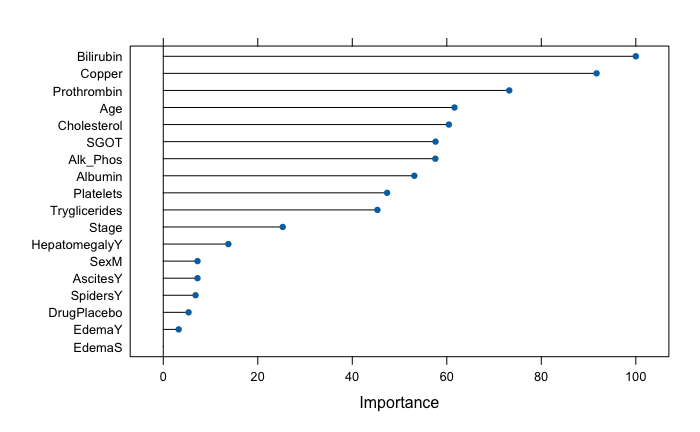

```r
# Get feature importance using varImp
importance <- varImp(rf_model)

# Plot feature importance
plot(importance, top = 18)
```

### Prediction and confusion matrix

By making predictions on the test set and evaluating the model using a confusion matrix, it is possible to assess the model’s accuracy, precision, recall, and other performance metrics. This step enables an understanding of how effectively the model generalises to new data.

```r
# Make predictions
rf_predictions <- predict(rf_model, dataTest)

# Evaluate the Random Forest model
confusionMatrix(rf_predictions, dataTest$Status)
```

```
Confusion Matrix and Statistics

          Reference
Prediction  C CL  D
        C  24  1  6
        CL  0  0  0
        D   5  2 16

Overall Statistics

               Accuracy : 0.7407
                 95% CI : (0.6035, 0.8504)
    No Information Rate : 0.537
    P-Value [Acc > NIR] : 0.001713

                  Kappa : 0.4997

 Mcnemar's Test P-Value : 0.377820

Statistics by Class:

                     Class: C Class: CL Class: D
Sensitivity            0.8276   0.00000   0.7273
Specificity            0.7200   1.00000   0.7812
Pos Pred Value         0.7742       NaN   0.6957
Neg Pred Value         0.7826   0.94444   0.8065
Prevalence             0.5370   0.05556   0.4074
Detection Rate         0.4444   0.00000   0.2963
Detection Prevalence   0.5741   0.00000   0.4259
Balanced Accuracy      0.7738   0.50000   0.7543
```

The overall accuracy of the model is 74.07%, with a 95% confidence interval ranging from 60.35% to 85.04%. This indicates that the model performs significantly better than random chance, as shown by the P-Value (0.001713). The Kappa statistic of 0.4997 suggests moderate agreement between the predicted and actual classifications.

Examining the statistics by class, the following observations can be made: - **Class C**: Sensitivity is 82.76%, indicating a high true positive rate for detecting Censored patients. Specificity is 72.00%, meaning a good true negative rate. The Positive Predictive Value (PPV) is 77.42%, and the Negative Predictive Value (NPV) is 78.26%. - **Class CL**: Sensitivity is 0%, indicating the model failed to identify any patients correctly as CL. Specificity is 100%, reflecting perfect true negative predictions, but the PPV is not applicable and the NPV is 94.44%. - **Class D**: Sensitivity is 72.73%, showing a good true positive rate for detecting Dead patients. Specificity is 78.12%, and PPV is 69.57%. The NPV is 80.65%.

The balanced accuracy for the classes is 77.38% for C, 50.00% for CL (poor performance), and 75.43% for D. These statistics highlight the model’s strengths in predicting C and D classes while pointing out significant weaknesses in predicting the CL class.

### Final Prediction and evaluation

To conclude, the prediction and evaluation process is repeated. This final evaluation ensures consistency and reliability of the results, validating the model’s effectiveness.

```r
# Make final predictions
final_rf_predictions <- predict(rf_model, dataTest)

# Final evaluation
confusionMatrix(final_rf_predictions, dataTest$Status)
```

```
Confusion Matrix and Statistics

          Reference
Prediction  C CL  D
        C  24  1  6
        CL  0  0  0
        D   5  2 16

Overall Statistics

               Accuracy : 0.7407
                 95% CI : (0.6035, 0.8504)
    No Information Rate : 0.537
    P-Value [Acc > NIR] : 0.001713

                  Kappa : 0.4997

 Mcnemar's Test P-Value : 0.377820

Statistics by Class:

                     Class: C Class: CL Class: D
Sensitivity            0.8276   0.00000   0.7273
Specificity            0.7200   1.00000   0.7812
Pos Pred Value         0.7742       NaN   0.6957
Neg Pred Value         0.7826   0.94444   0.8065
Prevalence             0.5370   0.05556   0.4074
Detection Rate         0.4444   0.00000   0.2963
Detection Prevalence   0.5741   0.00000   0.4259
Balanced Accuracy      0.7738   0.50000   0.7543
```

The results show the same values as the first evaluation. This indicates that the model’s performance is consistent.

# Results and Next Steps

The question if it is possible with this model to predict the Status of a patient based on the given features can in general be answered with yes. The analysis showed, that the model achieves an overall accuracy of approximately 74% with the optimal mtry value of 2. The kappa value of 0.4997 indicates, that the level of agreement between the predicted and actual value is as expected and underlines the functionality of the model. In a way it makes sense that the model cannot predict patients that are censored due to a liver transplant (Status = CL), as this procedure is dependent on much more factors than there are in this study, e.g. insurance status, position on waiting list, number of liver transplantation etc.

The variable importance in chapter 3.2.3 shows, that especially the value of the Bilirubin and the urine copper are significant features that have an impact on the prediction capabilities of the model.

The next steps could be to have a look at the Features of importance (Chapter 3.2.3) and focus only on those. There can be also other models applied to further investigate the prediction accuracy.